# Project1_SpookyData_text_minging

# Project and Data Description

This project is about the Natural Language Processing (NLP). The dataset comes from Kaggle Spooky Author Identification. In this project, besides reproduction of the tutorial, new findings: Section 1 Use streaming method to process data Comparing streaming and non-steaming differences in top frequency words in both world cloud and top frequency used for each author Section 2 Explore punctuation mark feature such as comma and semicolon as features Convert those features into numerical features Classification by using Principal Component Analysis (PCA) method Section 3 Sentimental analysis in sentence level Comparing results of sentimental analysis in both words and sentence level

The data set is a 19579 x 3 matrix. There are three columns: “id”, “text” and “author”, and 19579 rows of text from three popular horror authors: Edgar Allan Poe (EAP), HP Lovecraft (HPL), and Mary Wollstonecraft Shelley (MWS).

## Description of Authors

Edgar Allan Poe was an American writer, editor, and literary critic. Poe is best known for this poetry and short stories. His writing style was recognized as typical “Gothic” style which presented either death, lost love or both. Masterpiece: The Fall of the House of Usher, The Tell-Tale Heart, The Raven Howard Philips Lovecraft: HP Lovecraft was an American author of fantasy, horror, and science fiction. His writing style was the “cosmism” or “cosmic horror”. It means life is incomprehensible to humankind and universe is inimical to the interest of humankind. Masterpiece: The Complete Fiction of H. P. Lovecraft, The Call of Cthulhu, Great Tales of Horror Mary Wollstonecraft Shelley: Mary Wollstonecraft Shelly was an English author of a horror novel. Her most famous novel is Frankenstein or Modern Prometheus. Shelley was good at combining love and horror and shown the romantic features in her horror novel. Masterpiece: Frankenstein, Modern Prometheus

# Section 0: Package Used and Load

```r
# R package load
library(ggplot2)
library(dplyr)
library(tibble)
library(tidyr)
library(stringr)
library(tidytext)
library(topicmodels)
library(wordcloud)
library(ggridges)
library(textstem)
library(compare)
library(devtools)
library(pca3d)
library(wordcloud2)
```

## Multiple plot function

```r
# Reference: http://www.cookbook-r.com/Graphs/Multiple_graphs_on_one_page_(ggplot2)/
# ggplot objects can be passed in ..., or to plotlist (as a list of ggplot objects)
# - cols:   Number of columns in layout
# - layout: A matrix specifying the layout. If present, 'cols' is ignored.
#
# If the layout is something like matrix(c(1,2,3,3), nrow=2, byrow=TRUE),
# then plot 1 will go in the upper left, 2 will go in the upper right, and
# 3 will go all the way across the bottom.
#
multiplot <- function(..., plotlist=NULL, file, cols=1, layout=NULL) {
  require(grid)

  # Make a list from the ... arguments and plotlist
  plots <- c(list(...), plotlist)

  numPlots = length(plots)

  # If layout is NULL, then use 'cols' to determine layout
  if (is.null(layout)) {
    # Make the panel
    # ncol: Number of columns of plots
    # nrow: Number of rows needed, calculated from # of cols
    layout <- matrix(seq(1, cols * ceiling(numPlots/cols)),
                    ncol = cols, nrow = ceiling(numPlots/cols))
  }

 if (numPlots==1) {
    print(plots[[1]])

  } else {
    # Set up the page
    grid.newpage()
    pushViewport(viewport(layout = grid.layout(nrow(layout), ncol(layout))))

    # Make each plot, in the correct location
    for (i in 1:numPlots) {
      # Get the i,j matrix positions of the regions that contain this subplot
      matchidx <- as.data.frame(which(layout == i, arr.ind = TRUE))

      print(plots[[i]], vp = viewport(layout.pos.row = matchidx$row,
                                      layout.pos.col = matchidx$col))
    }
  }
}
```

# Section 1: Data cleaning and visualation

Read the data and process sentences to one word per row. Also, stream words by use the function Try to split sentences into two or three words per row to explore some meaningful features.

## Tokenization & Streaming

```r
# Read the data
spooky <- read.csv('../data/spooky.csv', as.is = TRUE)

sum(is.na(spooky))
```

```
## [1] 0
```

```r
spooky$author <- as.factor(spooky$author)


# Make a table with one word per row and remove `stop words` (i.e. the common words).
spooky_wrd <- unnest_tokens(spooky, word, text)
spooky_wrd <- anti_join(spooky_wrd, stop_words, by = "word")

# Streaming
spooky_wrd1 <- spooky_wrd
spooky_wrd1$stem <- stem_words(spooky_wrd1$word, language = "porter")
```

Streaming helps combine some words with same meaning.However, by observing the data set after streaming, there are some problems exist. For example, “happy” becomes “happi” after streaming. This would have a negative impact on some analysis especially the sentimental analysis.

## Make a table with two or three words per row and remove ‘stop words’

```r
# Set n=2 to split words, so two words are considered as one cell in the dataset
spooky_wrd2 <- unnest_tokens(spooky, word, text, token = "skip_ngrams", n = 2)
spooky_wrd2 <- anti_join(spooky_wrd2, stop_words, by = "word")

# Set n=2
spooky_wrd3 <- unnest_tokens(spooky, word, text, token = "skip_ngrams", n = 3)
spooky_wrd3 <- anti_join(spooky_wrd3, stop_words, by = "word")
```

## Wordcloud for single words with and without streaming

```r
# Explore words without streaming frequency
x <- count(group_by(spooky_wrd, word))
words <- x$word
freqs <- x$n
x <- x[order(-x$n),]


wordcloud2(x[1:150,], size= 1.0, shape = "round")
```

[interactive chart not shown]

## Wordcloud for streaming words

```r
# Explore words with streaming frequency
x1 <- count(group_by(spooky_wrd1, stem))
words1 <- x1$stem
freqs1 <- x1$n
x1 <- x1[order(-x1$n),]


wordcloud2(x1[1:150,], size= 1.0, shape = "round")
```

[interactive chart not shown]

Comparing two-word clouds, after streaming the frequency of certain words increasing such as “hoop” and “pass”. Some serious problems are happened such as “eye” becoming “ey”, “y” at the end becoming “i”.

## Compare differences between streaming and non-streaming words in top 50 frequently.

```r
x3 <- x[order(-x$n),]
x4 <- x1[order(-x1$n),]

# compare the top 50 frequencies words between streaming and non-streaming datasets
comparison <- cbind(x3$word[1:50], x3$n[1:50], x4$stem[1:50], x4$n[1:50])
comparison <- data.frame(comparison)
names(comparison) <- c("word non-streaming","frequency1", "word streaming", "frequency2")
comparison
```

| word non-streaming | frequency1 | word streaming | frequency2 |
| --- | --- | --- | --- |
| time | 729 | time | 873 |
| life | 563 | dai | 737 |
| found | 559 | ey | 711 |
| night | 559 | night | 584 |
| eyes | 540 | found | 576 |
| day | 516 | life | 563 |
| death | 380 | love | 535 |
| mind | 377 | hand | 474 |
| heart | 370 | hous | 466 |
| heard | 366 | natur | 433 |

[output cut: 40 more lines]

This table of comparison makes it clear that the changes of frequencies between streaming words list and non-streaming words list.

## Wordcloud for two-words per row

```r
# Explore words with streaming frequency
xx1 <- count(group_by(spooky_wrd2, word))
xx1 <- xx1[order(-xx1$n),]


wordcloud2(xx1[1:150,], size= 1.0, shape = "round")
```

[interactive chart not shown]

## Wordcloud for three-words per row

```r
# Explore words with streaming frequency
xxx1 <- count(group_by(spooky_wrd3, word))
xxx1 <- xxx1[order(-xx1$n),]


wordcloud2(xxx1[1:150,], size= 1.0, shape = "round")
```

[interactive chart not shown]

The word cloud for two-words or three-words is not very meaningful. The high-frequency terms usually do not have any information. However, it can be improved by advanced algorithms or dictionary to recognize the phrase rather than split into every two words.

## Plot the most frequent streaming words used each author

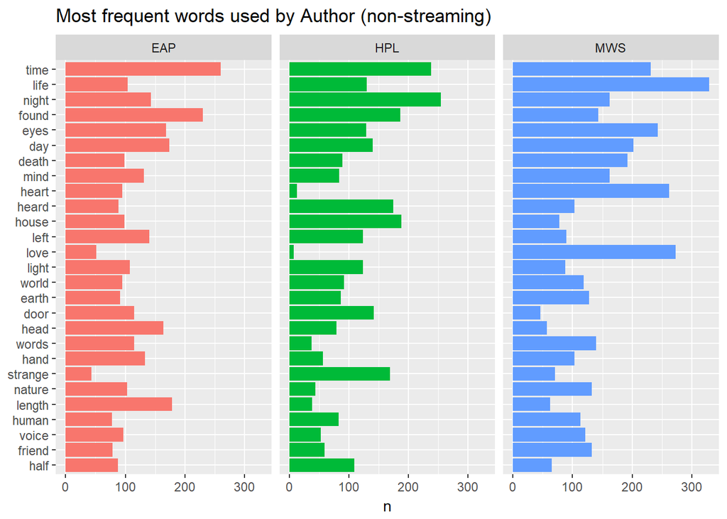

```r
# Counts number of times each author used each word.
author_words <- count(group_by(spooky_wrd1, stem, author))

# Counts number of times each word was used.
all_words    <- rename(count(group_by(spooky_wrd1, stem)), all = n)

author_words <- left_join(author_words, all_words, by = "stem")
author_words <- arrange(author_words, desc(all))
author_words <- ungroup(head(author_words, 81))

f1 <- ggplot(author_words) +
  geom_col(aes(reorder(stem, all, FUN = min), n, fill = author)) +
  xlab(NULL) +
  coord_flip() +
  facet_wrap(~ author) +
  theme(legend.position = "none")+
  ggtitle("Most frequent words used by Author (streaming)")

# Counts number of times each author used each word.
author_words <- count(group_by(spooky_wrd, word, author))

# Counts number of times each word was used.
all_words    <- rename(count(group_by(spooky_wrd, word)), all = n)

author_words <- left_join(author_words, all_words, by = "word")
author_words <- arrange(author_words, desc(all))
author_words <- ungroup(head(author_words, 81))

f2 <- ggplot(author_words) +
  geom_col(aes(reorder(word, all, FUN = min), n, fill = author)) +
  xlab(NULL) +
  coord_flip() +
  facet_wrap(~ author) +
  theme(legend.position = "none")+
  ggtitle("Most frequent words used by Author (non-streaming)")

#png("../figs/Most frequent words used by Author (non-streaming).png")
f2
```

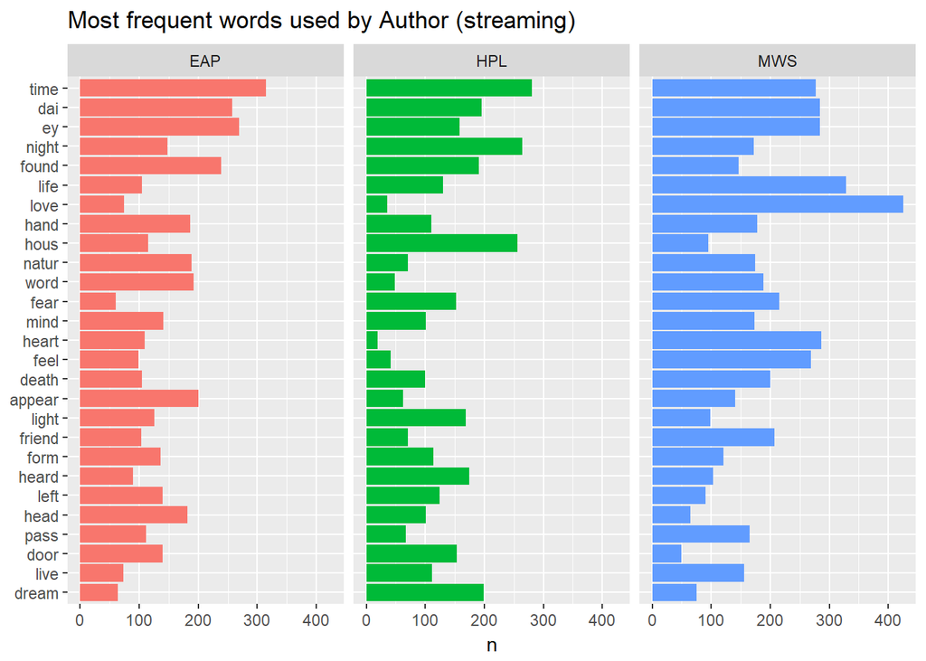

```r
#dev.off()


#png("../figs/Most frequent words used by Author (streaming).png")
f1
```

```r
#dev.off()
```

It is a better visualization of words frequencies for differences with or without streaming.

# Section 2: Converting punctuation mark features to numerical features and Clustering

## Punctuation mark features

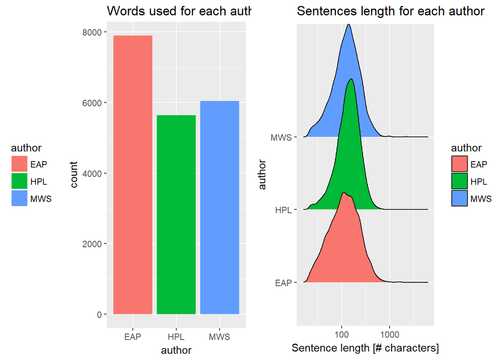

```r
# Initialize the punctuation mark features
SPspooky <- spooky
SPspooky$comma      <- 0
SPspooky$semicolon  <- 0
SPspooky$quote      <- 0

# Convert string features into numerical features
SPspooky$comma[1:19579]        <- as.numeric(str_count(SPspooky$text[1:19579], ','))
SPspooky$semicolon[1:19579]    <- as.numeric(str_count(SPspooky$text[1:19579], ';'))
SPspooky$quote[1:19579]        <- as.numeric(str_count(SPspooky$text[1:19579], '"'))
SPspooky$sen_length <- str_length(SPspooky$text)

# Plot the length of sentences
p1 <- ggplot(SPspooky) +
      geom_bar(aes(author, fill = author)) +
      theme(legend.position = "left")+
      ggtitle("Words used for each author")


p2 <- ggplot(SPspooky) +
      geom_density_ridges(aes(sen_length, author, fill = author)) +
      scale_x_log10() +
      theme(legend.position = "right") +
      labs(x = "Sentence length [# characters]")+
      ggtitle("Sentences length for each author")

#png("../figs/Author words used and sentences length.png")
multiplot(p1, p2, cols =2)
```

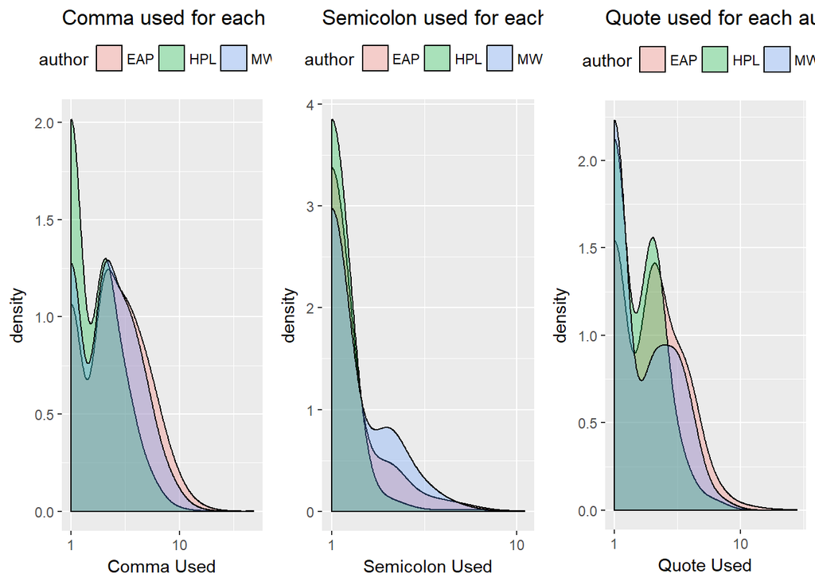

```r
#dev.off()



# Plot punctuation features for each author
p3 <- ggplot(SPspooky,aes(x= comma, fill = author, )) +
      geom_density( bw = 0.1, alpha = 0.3) +
      scale_x_log10() +
      theme(legend.position = "top") +
      labs(x = "Comma Used")+
      ggtitle("Comma used for each author")

p4 <- ggplot(SPspooky) +
      geom_density(aes(semicolon, fill = author), bw = 0.1, alpha = 0.3) +
      scale_x_log10() +
      theme(legend.position = "top") +
      labs(x = "Semicolon Used")+
      ggtitle("Semicolon used for each author")

p5 <- ggplot(SPspooky) +
      geom_density(aes(quote, fill = author), bw = 0.1, alpha = 0.3) +
      scale_x_log10() +
      theme(legend.position="top")+
      labs(x = "Quote Used")+
      ggtitle("Quote used for each author")


#png("../figs/Punctuation marks frequences for each author.png")
multiplot(p3,p4,p5, cols =3)
```

```r
#dev.off()
```

## Classification Based on features explored above

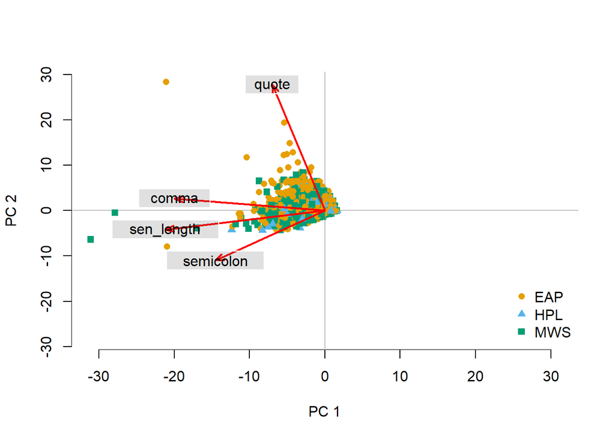

```r
# Use PCA method to do classification
pca = prcomp(SPspooky[,4:7], scale. = TRUE)
p <- pca2d(pca, group=SPspooky$author, legend="bottomright",biplot=TRUE, biplot.vars=4, title = 'PCA plot for punctuation marks and length of sentences')
```

```r
#png("../figs/PCA Clastering Plot.png")
#pca2d(pca, group=SPspooky$author, legend="bottomright",biplot=TRUE, biplot.vars=4)
#dev.off()
```

Explore feature of punctuation marks such as “,”, “;” and “’”. Try to do classification by using PCA methods. However, the plots show comma and semicolon are in the same direction with sentence length. and the quote is relatively less related to the other three. It is reasonable. When the length of sentences becomes longer, it tends to have more comma or semicolon. Thus, it is hard to use the length of sentences, comma, semicolon to predict the author. However, at the quote direction, there are more yellow dots concentrated. It means EAP tends to use more quote than other two authors. In other words, EAP would have more dialogs than the other two authors.

# Section 3: Sentiment Analysis

## Sentimental Analysis in Word Level

```r
# Keep words that have been classified into the NRC lexicon.
nrc <- get_sentiments('nrc')
sentiments  <- inner_join(spooky_wrd, get_sentiments('nrc'), by = "word")


count(sentiments, sentiment)
```

| sentiment | n |
| --- | --- |
| anger | 9869 |
| anticipation | 11258 |
| disgust | 7697 |
| fear | 13927 |
| joy | 10190 |
| negative | 23674 |
| positive | 25175 |
| sadness | 12674 |
| surprise | 6200 |
| trust | 13655 |

```r
count(sentiments, author, sentiment)
```

| author | sentiment | n |
| --- | --- | --- |
| EAP | anger | 2962 |
| EAP | anticipation | 3982 |
| EAP | disgust | 2261 |
| EAP | fear | 4194 |
| EAP | joy | 3302 |
| EAP | negative | 7659 |
| EAP | positive | 9291 |
| EAP | sadness | 3938 |
| EAP | surprise | 2245 |
| EAP | trust | 5116 |

[output cut: 20 more lines]

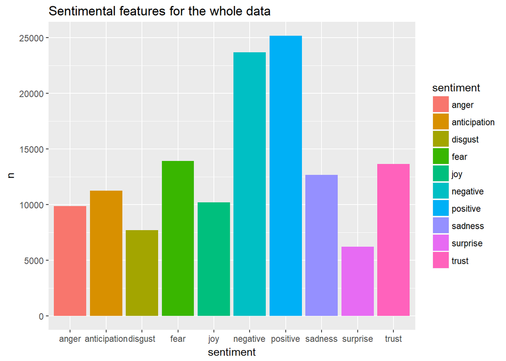

```r
#png("../figs/Sentimental analysis.png")
ggplot(count(sentiments, sentiment)) +
  geom_col(aes(sentiment, n, fill = sentiment))+
  ggtitle("Sentimental features for the whole data")
```

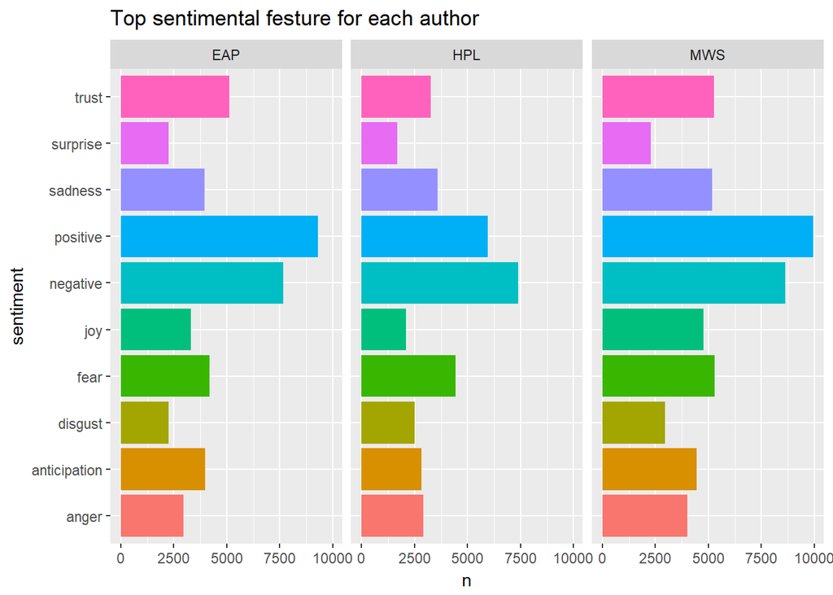

```r
#dev.off()

#png("../figs//Sentimental analysis for each author.png")
ggplot(count(sentiments, author, sentiment)) +
  geom_col(aes(sentiment, n, fill = sentiment)) +
  facet_wrap(~ author) +
  coord_flip() +
  theme(legend.position = "none")+
  ggtitle("Top sentimental festure for each author")
```

```r
#dev.off()
```